# Analysis2: agreement among independent packet reviewers

2026-10-08

## Purpose and design

Agreement is evaluated among the same 7 independent reviewers who assigned ratings from identical clinical information packets. The primary analysis uses one participant per row and one reviewer per column. It estimates agreement conditional on the information supplied; shared omissions or errors in the packets may coexist with high agreement. Initial ratings measure independent packet interpretation. Ratings following discussion measure agreement under the consensus procedure, which creates dependence between reviewers and limits interpretation as independent reliability.

The reviewer response specifies Conger’s generalized κ for this fixed reviewer panel (Internal: REFERENCES/AMGP-26-510-reviews-RESPONSES.md, Reviewer 1, comments 1–3). Its chance-agreement component retains each reviewer’s category distribution. Quadratic category weights for severity are 1 minus the squared score difference divided by 100, with all 11 categories (0–10) retained in every subgroup. Binary presence uses identity weights for categories 0 and 1. Category weights describe the cost of rating disagreement; participant sampling weights describe the target participant distribution.

The unweighted overall estimate is primary. Kendall’s W summarizes concordance in ranking, and an ICC depends on a variance-components model and a choice of absolute agreement or consistency; these alternatives would require separate analytic specifications. Pearson correlations are excluded from this report.

## Inputs and missing ratings

The import and participant-level harmonization were adapted from Analysis1’s 030, 040, and 045 scripts. The local workbook is `SourceData/FINAL RS IRR Ratings.xlsx`; the parent-cohort inputs are `BASILIIMainStudy_Derived.dta` and `n488.dta` in the relative folder specified in this control file. As in Analysis1, Tamara’s rows are excluded, participant identifiers are trimmed before joining, and a rating without an arrow is carried forward as its post-discussion rating. Those carried-forward ratings do not establish that a case was discussed.

Available ratings are used without imputing absent reviewer scores. Each outcome is checked separately. Participants with fewer than 2 ratings or a reviewer with no ratings cause the run to stop. A complete-participant sensitivity estimate drops participants missing any of the 7 ratings for that outcome and stage. Missing dementia status is excluded only from dementia strata and is retained in the overall analysis.

Table 1. Availability of reviewer ratings by outcome and rating stage

| outcome_stage | participants | observed | missing | complete_participants | graphic_comparisons |
| --- | --- | --- | --- | --- | --- |
| severity_initial | 46 | 320 | 2 | 44 | 954 |
| severity_consensus | 46 | 320 | 2 | 44 | 954 |
| presence_initial | 46 | 320 | 2 | 44 | 954 |
| presence_consensus | 46 | 320 | 2 | 44 | 954 |

NOTES. outcome_stage: Outcome and rating stage; consensus denotes post-discussion ratings. participants: Number of participants in the rating matrix. observed: Number of nonmissing participant-reviewer ratings. missing: Number of absent ratings among the possible participant-reviewer ratings. complete_participants: Number of participants with all 7 reviewer ratings. graphic_comparisons: Number of observed unique reviewer pairs, summed across participants.

Table 2. Available ratings by anonymous reviewer

| reviewer | severity_initial | severity_consensus | presence_initial | presence_consensus |
| --- | --- | --- | --- | --- |
| Reviewer1 | 46 | 46 | 46 | 46 |
| Reviewer2 | 46 | 46 | 46 | 46 |
| Reviewer3 | 46 | 46 | 46 | 46 |
| Reviewer4 | 46 | 46 | 46 | 46 |
| Reviewer5 | 46 | 46 | 46 | 46 |
| Reviewer6 | 44 | 44 | 44 | 44 |
| Reviewer7 | 46 | 46 | 46 | 46 |

NOTES. reviewer: Anonymous identifier for a fixed member of the 7-reviewer panel. severity_initial: Number of available initial severity ratings. severity_consensus: Number of available post-discussion severity ratings. presence_initial: Number of available initial presence ratings. presence_consensus: Number of available post-discussion presence ratings.

Table 3. Reliability sample and reference-standard dementia status

| measure | count |
| --- | --- |
| Reliability participants | 46 |
| Reference-standard dementia present | 27 |
| Reference-standard dementia absent | 19 |
| Dementia status missing | 0 |

NOTES. measure: Sample count or reference-standard dementia category. count: Number of participants in the named category.

Table 4. Reference-standard delirium severity distribution in the reliability sample

| reference_standard_severity | participants |
| --- | --- |
| 0 | 21 |
| 1 | 4 |
| 3 | 2 |
| 4 | 7 |
| 5 | 4 |
| 6 | 5 |
| 7 | 2 |
| 8 | 1 |

NOTES. reference_standard_severity: Reference-standard delirium severity score, on the 0-10 scale. participants: Number of participants with the score shown.

Table 5. Distribution of reviewer-assigned delirium severity scores

| outcome_stage | severity | ratings | denominator |
| --- | --- | --- | --- |
| severity_initial | 0 | 109 | 320 |
| severity_initial | 1 | 43 | 320 |
| severity_initial | 2 | 17 | 320 |
| severity_initial | 3 | 18 | 320 |
| severity_initial | 4 | 30 | 320 |
| severity_initial | 5 | 39 | 320 |
| severity_initial | 6 | 30 | 320 |
| severity_initial | 7 | 20 | 320 |
| severity_initial | 8 | 7 | 320 |
| severity_initial | 9 | 7 | 320 |
| severity_initial | 10 | 0 | 320 |
| severity_consensus | 0 | 98 | 320 |
| severity_consensus | 1 | 48 | 320 |
| severity_consensus | 2 | 30 | 320 |
| severity_consensus | 3 | 12 | 320 |
| severity_consensus | 4 | 23 | 320 |
| severity_consensus | 5 | 40 | 320 |
| severity_consensus | 6 | 40 | 320 |
| severity_consensus | 7 | 17 | 320 |
| severity_consensus | 8 | 7 | 320 |
| severity_consensus | 9 | 5 | 320 |
| severity_consensus | 10 | 0 | 320 |

NOTES. outcome_stage: Initial or post-discussion severity ratings. severity: Reviewer-assigned delirium severity score, on the 0-10 scale. ratings: Number of observed ratings equal to the score shown. denominator: Total number of nonmissing ratings at that stage.

The manuscript describes 46 × 7 = 322 possible reviewer ratings. Two absent reviewer ratings remove 2 × 6 = 12 graphical comparisons, leaving 46 × 21 − 12 = 954 (Internal: REFERENCES/BASIL_CA_combined.pdf, p. 12). The audit above reports the counts obtained locally; it determines the captions rather than imposing 954 as an analysis sample size.

## Agreement and uncertainty

The primary estimate is computed with `irrCAC::conger.kappa.raw`. Installed irrCAC version: 1.4; R version: 4.6.1. The package’s category-weight matrix is supplied explicitly. A direct matrix implementation is checked against its point estimate on each estimable unweighted analysis, then used for bootstrap calculations and participant-weighted sensitivity analyses. The implementation follows the [irrCAC source](https://github.com/cran/irrCAC/blob/master/R/agree.coeff3.raw.r), with weighted participant means and reviewer category margins added for sensitivity analyses.

Uncertainty is summarized by percentile 95% confidence intervals from 2000 bootstrap samples of participants. All reviewer columns and the observed missingness pattern travel together. The same participant sample is used for initial and post-discussion κ when estimating their paired change. Reviewers are treated as a fixed panel, so these intervals describe uncertainty across participants conditional on the 7 reviewers; they do not quantify variation over a population of reviewers. No finite-population correction is applied because this was a selected reliability sample rather than a probability sample.

A bootstrap replicate with a missing reviewer margin or expected agreement of 1 has undefined κ. The number of finite replicates is reported, and an interval is withheld if fewer than 95% are finite. A coefficient is undefined when expected agreement equals 1. Perfect agreement across participants in multiple categories can yield κ = 1.

Table 6. Unweighted agreement: Delirium severity, initial ratings

| group | participants | metric | estimate | lower | upper | valid_bootstrap | attempted |
| --- | --- | --- | --- | --- | --- | --- | --- |
| Overall | 46 | Kappa | 0.844 | 0.774 | 0.885 | 2000 | 2000 |
| Overall | 46 | exact | 0.378 | 0.315 | 0.453 | 2000 | 2000 |
| Overall | 46 | within2 | 0.884 | 0.842 | 0.922 | 2000 | 2000 |
| Overall | 46 | MAD | 1.051 | 0.883 | 1.213 | 2000 | 2000 |
| No dementia | 19 | Kappa | 0.845 | 0.740 | 0.906 | 2000 | 2000 |
| No dementia | 19 | exact | 0.492 | 0.365 | 0.623 | 2000 | 2000 |
| No dementia | 19 | within2 | 0.902 | 0.847 | 0.957 | 2000 | 2000 |
| No dementia | 19 | MAD | 0.842 | 0.571 | 1.103 | 2000 | 2000 |
| Dementia | 27 | Kappa | 0.836 | 0.739 | 0.889 | 2000 | 2000 |
| Dementia | 27 | exact | 0.297 | 0.247 | 0.351 | 2000 | 2000 |
| Dementia | 27 | within2 | 0.871 | 0.817 | 0.924 | 2000 | 2000 |
| Dementia | 27 | MAD | 1.199 | 1.026 | 1.379 | 2000 | 2000 |

NOTES. group: Overall sample or stratum defined by reference-standard dementia status; missing dementia status is retained only in Overall. participants: Number of participants contributing ratings to the group. metric: Kappa: Conger’s generalized kappa (quadratic category weights for severity, identity weights for presence); exact: proportion of reviewer pairs with identical ratings; within2: proportion differing by at most 2 severity points; MAD: mean absolute severity difference in points. Descriptive measures are first calculated within participant, then averaged across participants. estimate: Point estimate of the measure named in metric; exact and within2 are on a 0-1 scale. lower: Lower limit of the percentile 95% participant-bootstrap confidence interval. upper: Upper limit of the percentile 95% participant-bootstrap confidence interval. valid_bootstrap: Number of bootstrap replicates with a finite estimate. attempted: Total number of bootstrap replicates attempted. Participants receive equal weight. Intervals condition on the fixed reviewer panel.

Table 7. Unweighted agreement: Delirium severity, post-discussion ratings

| group | participants | metric | estimate | lower | upper | valid_bootstrap | attempted |
| --- | --- | --- | --- | --- | --- | --- | --- |
| Overall | 46 | Kappa | 0.932 | 0.904 | 0.948 | 2000 | 2000 |
| Overall | 46 | exact | 0.476 | 0.417 | 0.539 | 2000 | 2000 |
| Overall | 46 | within2 | 1.000 | 1.000 | 1.000 | 2000 | 2000 |
| Overall | 46 | MAD | 0.670 | 0.581 | 0.755 | 2000 | 2000 |
| No dementia | 19 | Kappa | 0.937 | 0.897 | 0.957 | 2000 | 2000 |
| No dementia | 19 | exact | 0.577 | 0.466 | 0.689 | 2000 | 2000 |
| No dementia | 19 | within2 | 1.000 | 1.000 | 1.000 | 2000 | 2000 |
| No dementia | 19 | MAD | 0.526 | 0.376 | 0.682 | 2000 | 2000 |
| Dementia | 27 | Kappa | 0.926 | 0.883 | 0.944 | 2000 | 2000 |
| Dementia | 27 | exact | 0.405 | 0.354 | 0.460 | 2000 | 2000 |
| Dementia | 27 | within2 | 1.000 | 1.000 | 1.000 | 2000 | 2000 |
| Dementia | 27 | MAD | 0.772 | 0.684 | 0.856 | 2000 | 2000 |

NOTES. group: Overall sample or stratum defined by reference-standard dementia status; missing dementia status is retained only in Overall. participants: Number of participants contributing ratings to the group. metric: Kappa: Conger’s generalized kappa (quadratic category weights for severity, identity weights for presence); exact: proportion of reviewer pairs with identical ratings; within2: proportion differing by at most 2 severity points; MAD: mean absolute severity difference in points. Descriptive measures are first calculated within participant, then averaged across participants. estimate: Point estimate of the measure named in metric; exact and within2 are on a 0-1 scale. lower: Lower limit of the percentile 95% participant-bootstrap confidence interval. upper: Upper limit of the percentile 95% participant-bootstrap confidence interval. valid_bootstrap: Number of bootstrap replicates with a finite estimate. attempted: Total number of bootstrap replicates attempted. Participants receive equal weight. Intervals condition on the fixed reviewer panel.

Table 8. Unweighted agreement: Delirium presence, initial ratings

| group | participants | metric | estimate | lower | upper | valid_bootstrap | attempted |
| --- | --- | --- | --- | --- | --- | --- | --- |
| Overall | 46 | Kappa | 0.771 | 0.661 | 0.859 | 2000 | 2000 |
| Overall | 46 | exact | 0.887 | 0.836 | 0.931 | 2000 | 2000 |
| No dementia | 19 | Kappa | 0.756 | 0.581 | 0.891 | 2000 | 2000 |
| No dementia | 19 | exact | 0.882 | 0.810 | 0.955 | 2000 | 2000 |
| Dementia | 27 | Kappa | 0.781 | 0.619 | 0.901 | 2000 | 2000 |
| Dementia | 27 | exact | 0.891 | 0.817 | 0.954 | 2000 | 2000 |

NOTES. group: Overall sample or stratum defined by reference-standard dementia status; missing dementia status is retained only in Overall. participants: Number of participants contributing ratings to the group. metric: Kappa: Conger’s generalized kappa (quadratic category weights for severity, identity weights for presence); exact: proportion of reviewer pairs with identical ratings; within2: proportion differing by at most 2 severity points; MAD: mean absolute severity difference in points. Descriptive measures are first calculated within participant, then averaged across participants. estimate: Point estimate of the measure named in metric; exact and within2 are on a 0-1 scale. lower: Lower limit of the percentile 95% participant-bootstrap confidence interval. upper: Upper limit of the percentile 95% participant-bootstrap confidence interval. valid_bootstrap: Number of bootstrap replicates with a finite estimate. attempted: Total number of bootstrap replicates attempted. Participants receive equal weight. Intervals condition on the fixed reviewer panel.

Table 9. Unweighted agreement: Delirium presence, post-discussion ratings

| group | participants | metric | estimate | lower | upper | valid_bootstrap | attempted |
| --- | --- | --- | --- | --- | --- | --- | --- |
| Overall | 46 | Kappa | 0.810 | 0.702 | 0.896 | 2000 | 2000 |
| Overall | 46 | exact | 0.906 | 0.857 | 0.949 | 2000 | 2000 |
| No dementia | 19 | Kappa | 0.778 | 0.623 | 0.902 | 2000 | 2000 |
| No dementia | 19 | exact | 0.892 | 0.825 | 0.955 | 2000 | 2000 |
| Dementia | 27 | Kappa | 0.831 | 0.685 | 0.943 | 2000 | 2000 |
| Dementia | 27 | exact | 0.915 | 0.852 | 0.972 | 2000 | 2000 |

NOTES. group: Overall sample or stratum defined by reference-standard dementia status; missing dementia status is retained only in Overall. participants: Number of participants contributing ratings to the group. metric: Kappa: Conger’s generalized kappa (quadratic category weights for severity, identity weights for presence); exact: proportion of reviewer pairs with identical ratings; within2: proportion differing by at most 2 severity points; MAD: mean absolute severity difference in points. Descriptive measures are first calculated within participant, then averaged across participants. estimate: Point estimate of the measure named in metric; exact and within2 are on a 0-1 scale. lower: Lower limit of the percentile 95% participant-bootstrap confidence interval. upper: Upper limit of the percentile 95% participant-bootstrap confidence interval. valid_bootstrap: Number of bootstrap replicates with a finite estimate. attempted: Total number of bootstrap replicates attempted. Participants receive equal weight. Intervals condition on the fixed reviewer panel.

Table 10. Paired change in overall unweighted kappa following discussion

| outcome | estimate | lower | upper | valid_bootstrap | attempted |
| --- | --- | --- | --- | --- | --- |
| severity | 0.088 | 0.057 | 0.133 | 2000 | 2000 |
| presence | 0.039 | 0.005 | 0.083 | 2000 | 2000 |

NOTES. outcome: Delirium severity or delirium presence. estimate: Post-discussion kappa minus initial kappa; positive values indicate higher post-discussion agreement. lower: Lower limit of the percentile 95% participant-bootstrap confidence interval. upper: Upper limit of the percentile 95% participant-bootstrap confidence interval. valid_bootstrap: Number of bootstrap replicates with a finite estimate. attempted: Total number of bootstrap replicates attempted. Each bootstrap draw uses the same participants for both rating stages; the change is descriptive and does not identify a causal effect of discussion.

Table 11. Unweighted kappa among participants with complete reviewer ratings

| outcome_stage | group | n | kappa |
| --- | --- | --- | --- |
| severity_initial | Overall | 44 | 0.843 |
| severity_initial | No dementia | 18 | 0.843 |
| severity_initial | Dementia | 26 | 0.834 |
| severity_consensus | Overall | 44 | 0.934 |
| severity_consensus | No dementia | 18 | 0.939 |
| severity_consensus | Dementia | 26 | 0.926 |
| presence_initial | Overall | 44 | 0.776 |
| presence_initial | No dementia | 18 | 0.776 |
| presence_initial | Dementia | 26 | 0.773 |
| presence_consensus | Overall | 44 | 0.817 |
| presence_consensus | No dementia | 18 | 0.800 |
| presence_consensus | Dementia | 26 | 0.824 |

NOTES. outcome_stage: Outcome and rating stage; consensus denotes post-discussion ratings. group: Overall sample or stratum defined by reference-standard dementia status; missing dementia status is retained only in Overall. n: Number of participants with all 7 reviewer ratings for the outcome and stage. kappa: Conger’s generalized kappa, using quadratic category weights for severity and identity weights for presence.

Severity exact agreement, agreement within 2 points, and mean absolute difference (MAD) are calculated from category counts within each participant, then averaged across participants. A participant with 6 ratings contributes the same overall case weight as a participant with 7 ratings. This calculation preserves the original within-2-point definition without using a pooled all-pairs dataset for statistics. Binary exact agreement is summarized in the same manner. Proportions are shown on a 0–1 scale.

The dementia-stratified estimates are exploratory. They retain the full severity scale, but the observed category distribution may differ between strata and influence κ. Differences between subgroup coefficients cannot establish differences in reviewer performance, and similar estimates do not establish equivalence. The paired change describes the difference between stages; without a control group it cannot identify the causal effect of discussion.

## Participant weighting sensitivity

Entropy balancing matches the reliability sample to the full enrolled cohort on mean reference-standard delirium severity and the proportions at sites 2 and 3. The full cohort, including reliability participants, supplies the target means. Analysis1’s Treatment coding instead targeted participants outside the reliability sample (Internal: R/Analysis1/046-sampling_weights.R, lines 20–39). Analysis2 makes the intended full-cohort target explicit and checks the achieved balance before estimating weighted agreement.

Table 12. Covariate balance before and after entropy weighting

| variable | target | sample | weighted |
| --- | --- | --- | --- |
| severity | 1.719 | 2.391 | 1.719 |
| site2 | 0.342 | 0.304 | 0.342 |
| site3 | 0.207 | 0.478 | 0.207 |

NOTES. variable: severity: reference-standard delirium severity (0-10); site2 and site3: indicators for enrollment at sites 2 and 3. target: Mean in the full enrolled cohort, including reliability participants; site means are proportions. sample: Unweighted mean in the reliability sample. weighted: Entropy-weighted mean in the reliability sample.

Table 13. Distribution of entropy weights and effective sample size

| n | minimum | maximum | ESS |
| --- | --- | --- | --- |
| 46 | 0.198 | 2.836 | 30.208 |

NOTES. n: Number of participants with entropy weights. minimum: Smallest participant weight. maximum: Largest participant weight. ESS: Effective sample size: squared sum of weights divided by the sum of squared weights. Weights are normalized to sum to the number of reliability participants.

Table 14. Entropy-weighted agreement sensitivity analysis: Delirium severity, initial ratings

| group | participants | metric | estimate | lower | upper | valid_bootstrap | attempted |
| --- | --- | --- | --- | --- | --- | --- | --- |
| Overall | 46 | Kappa | 0.825 | -0.475 | 2.391 | 2000 | 2000 |
| Overall | 46 | exact | 0.441 | 0.343 | 0.549 | 2000 | 2000 |
| Overall | 46 | within2 | 0.888 | 0.842 | 0.934 | 2000 | 2000 |
| Overall | 46 | MAD | 0.941 | 0.732 | 1.158 | 2000 | 2000 |
| No dementia | 19 | Kappa | 1.020 | 1.006 | 1.089 | 2000 | 2000 |
| No dementia | 19 | exact | 0.526 | 0.367 | 0.685 | 2000 | 2000 |
| No dementia | 19 | within2 | 0.904 | 0.832 | 0.964 | 2000 | 2000 |
| No dementia | 19 | MAD | 0.789 | 0.473 | 1.132 | 2000 | 2000 |
| Dementia | 27 | Kappa | 0.957 | 0.911 | 0.972 | 2000 | 2000 |
| Dementia | 27 | exact | 0.313 | 0.261 | 0.361 | 2000 | 2000 |
| Dementia | 27 | within2 | 0.865 | 0.802 | 0.926 | 2000 | 2000 |
| Dementia | 27 | MAD | 1.169 | 1.024 | 1.354 | 2000 | 2000 |

NOTES. group: Overall sample or stratum defined by reference-standard dementia status; missing dementia status is retained only in Overall. participants: Number of participants contributing ratings to the group. metric: Kappa: Conger’s generalized kappa (quadratic category weights for severity, identity weights for presence); exact: proportion of reviewer pairs with identical ratings; within2: proportion differing by at most 2 severity points; MAD: mean absolute severity difference in points. Descriptive measures are first calculated within participant, then averaged across participants. estimate: Point estimate of the measure named in metric; exact and within2 are on a 0-1 scale. lower: Lower limit of the percentile 95% participant-bootstrap confidence interval. upper: Upper limit of the percentile 95% participant-bootstrap confidence interval. valid_bootstrap: Number of bootstrap replicates with a finite estimate. attempted: Total number of bootstrap replicates attempted. Participant weights target full-cohort covariate means and remain fixed during bootstrap resampling. Intervals omit weight-estimation uncertainty and condition on the fixed reviewer panel.

Table 15. Entropy-weighted agreement sensitivity analysis: Delirium severity, post-discussion ratings

| group | participants | metric | estimate | lower | upper | valid_bootstrap | attempted |
| --- | --- | --- | --- | --- | --- | --- | --- |
| Overall | 46 | Kappa | 0.929 | 0.583 | 1.416 | 2000 | 2000 |
| Overall | 46 | exact | 0.532 | 0.449 | 0.620 | 2000 | 2000 |
| Overall | 46 | within2 | 1.000 | 1.000 | 1.000 | 2000 | 2000 |
| Overall | 46 | MAD | 0.589 | 0.473 | 0.707 | 2000 | 2000 |
| No dementia | 19 | Kappa | 1.007 | 1.002 | 1.035 | 2000 | 2000 |
| No dementia | 19 | exact | 0.616 | 0.500 | 0.738 | 2000 | 2000 |
| No dementia | 19 | within2 | 1.000 | 1.000 | 1.000 | 2000 | 2000 |
| No dementia | 19 | MAD | 0.463 | 0.314 | 0.620 | 2000 | 2000 |
| Dementia | 27 | Kappa | 0.981 | 0.957 | 0.986 | 2000 | 2000 |
| Dementia | 27 | exact | 0.405 | 0.352 | 0.478 | 2000 | 2000 |
| Dementia | 27 | within2 | 1.000 | 1.000 | 1.000 | 2000 | 2000 |
| Dementia | 27 | MAD | 0.778 | 0.672 | 0.862 | 2000 | 2000 |

NOTES. group: Overall sample or stratum defined by reference-standard dementia status; missing dementia status is retained only in Overall. participants: Number of participants contributing ratings to the group. metric: Kappa: Conger’s generalized kappa (quadratic category weights for severity, identity weights for presence); exact: proportion of reviewer pairs with identical ratings; within2: proportion differing by at most 2 severity points; MAD: mean absolute severity difference in points. Descriptive measures are first calculated within participant, then averaged across participants. estimate: Point estimate of the measure named in metric; exact and within2 are on a 0-1 scale. lower: Lower limit of the percentile 95% participant-bootstrap confidence interval. upper: Upper limit of the percentile 95% participant-bootstrap confidence interval. valid_bootstrap: Number of bootstrap replicates with a finite estimate. attempted: Total number of bootstrap replicates attempted. Participant weights target full-cohort covariate means and remain fixed during bootstrap resampling. Intervals omit weight-estimation uncertainty and condition on the fixed reviewer panel.

Table 16. Entropy-weighted agreement sensitivity analysis: Delirium presence, initial ratings

| group | participants | metric | estimate | lower | upper | valid_bootstrap | attempted |
| --- | --- | --- | --- | --- | --- | --- | --- |
| Overall | 46 | Kappa | 0.746 | 0.183 | 0.864 | 2000 | 2000 |
| Overall | 46 | exact | 0.885 | 0.831 | 0.936 | 2000 | 2000 |
| No dementia | 19 | Kappa | 1.685 | -4.074 | 6.205 | 2000 | 2000 |
| No dementia | 19 | exact | 0.890 | 0.815 | 0.959 | 2000 | 2000 |
| Dementia | 27 | Kappa | 0.837 | 0.715 | 0.933 | 2000 | 2000 |
| Dementia | 27 | exact | 0.878 | 0.797 | 0.952 | 2000 | 2000 |

NOTES. group: Overall sample or stratum defined by reference-standard dementia status; missing dementia status is retained only in Overall. participants: Number of participants contributing ratings to the group. metric: Kappa: Conger’s generalized kappa (quadratic category weights for severity, identity weights for presence); exact: proportion of reviewer pairs with identical ratings; within2: proportion differing by at most 2 severity points; MAD: mean absolute severity difference in points. Descriptive measures are first calculated within participant, then averaged across participants. estimate: Point estimate of the measure named in metric; exact and within2 are on a 0-1 scale. lower: Lower limit of the percentile 95% participant-bootstrap confidence interval. upper: Upper limit of the percentile 95% participant-bootstrap confidence interval. valid_bootstrap: Number of bootstrap replicates with a finite estimate. attempted: Total number of bootstrap replicates attempted. Participant weights target full-cohort covariate means and remain fixed during bootstrap resampling. Intervals omit weight-estimation uncertainty and condition on the fixed reviewer panel.

Table 17. Entropy-weighted agreement sensitivity analysis: Delirium presence, post-discussion ratings

| group | participants | metric | estimate | lower | upper | valid_bootstrap | attempted |
| --- | --- | --- | --- | --- | --- | --- | --- |
| Overall | 46 | Kappa | 0.791 | 0.358 | 0.902 | 2000 | 2000 |
| Overall | 46 | exact | 0.903 | 0.849 | 0.951 | 2000 | 2000 |
| No dementia | 19 | Kappa | 1.676 | -5.291 | 7.200 | 2000 | 2000 |
| No dementia | 19 | exact | 0.895 | 0.824 | 0.962 | 2000 | 2000 |
| Dementia | 27 | Kappa | 0.888 | 0.788 | 0.966 | 2000 | 2000 |
| Dementia | 27 | exact | 0.916 | 0.844 | 0.977 | 2000 | 2000 |

NOTES. group: Overall sample or stratum defined by reference-standard dementia status; missing dementia status is retained only in Overall. participants: Number of participants contributing ratings to the group. metric: Kappa: Conger’s generalized kappa (quadratic category weights for severity, identity weights for presence); exact: proportion of reviewer pairs with identical ratings; within2: proportion differing by at most 2 severity points; MAD: mean absolute severity difference in points. Descriptive measures are first calculated within participant, then averaged across participants. estimate: Point estimate of the measure named in metric; exact and within2 are on a 0-1 scale. lower: Lower limit of the percentile 95% participant-bootstrap confidence interval. upper: Upper limit of the percentile 95% participant-bootstrap confidence interval. valid_bootstrap: Number of bootstrap replicates with a finite estimate. attempted: Total number of bootstrap replicates attempted. Participant weights target full-cohort covariate means and remain fixed during bootstrap resampling. Intervals omit weight-estimation uncertainty and condition on the fixed reviewer panel.

The `weights` argument of `conger.kappa.raw` specifies category agreement weights, not participant sampling weights. Participant-weighted κ is therefore a separate matrix extension, labelled as sensitivity analysis, rather than a claim that irrCAC supports case weights. Participant weights enter both observed agreement and each reviewer’s category margins. They are held fixed within bootstrap samples; those intervals condition on the estimated weights and target moments and omit weight-estimation uncertainty. The full-cohort interpretation requires that the selected cases adequately represent rating behavior after balancing the measured covariates. Balancing cannot establish that assumption.

The effective sample size (ESS) is the squared sum of participant weights divided by their sum of squares. Its relation to the number of reliability participants helps identify concentration of weights. Weighted subgroup estimates inherit the overall weights; no separate dementia target is imposed.

## Descriptive pooled reviewer-pair displays

The displays include all observed unique reviewer pairs within each participant. The first and second reviewer refer to the lower and higher fixed reviewer-column indices, respectively; they do not identify 2 particular reviewers. Each participant contributes multiple dependent points. Point sizes show raw comparison counts. These graphics use no participant weights and contain no pooled κ, correlation, regression test, or confidence interval.

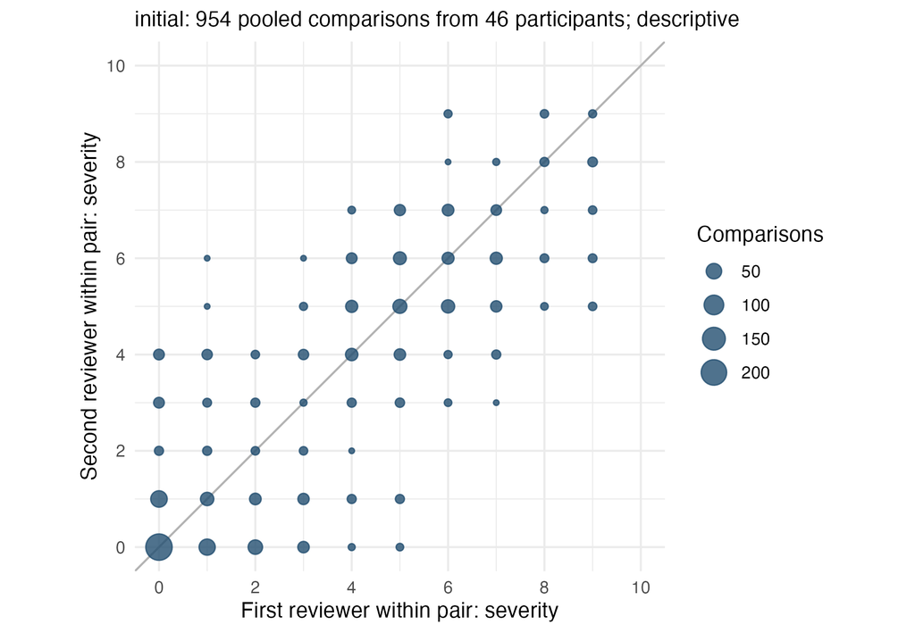

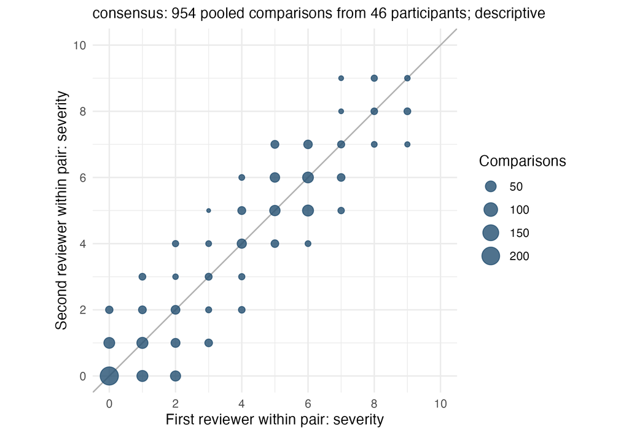

## Differences across severity levels

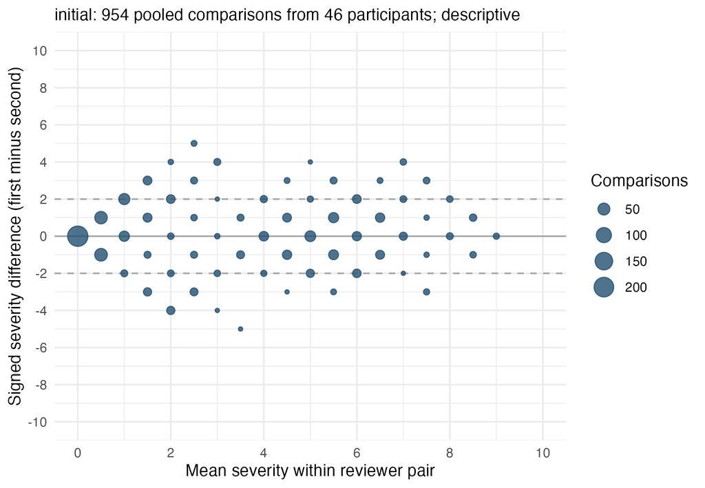

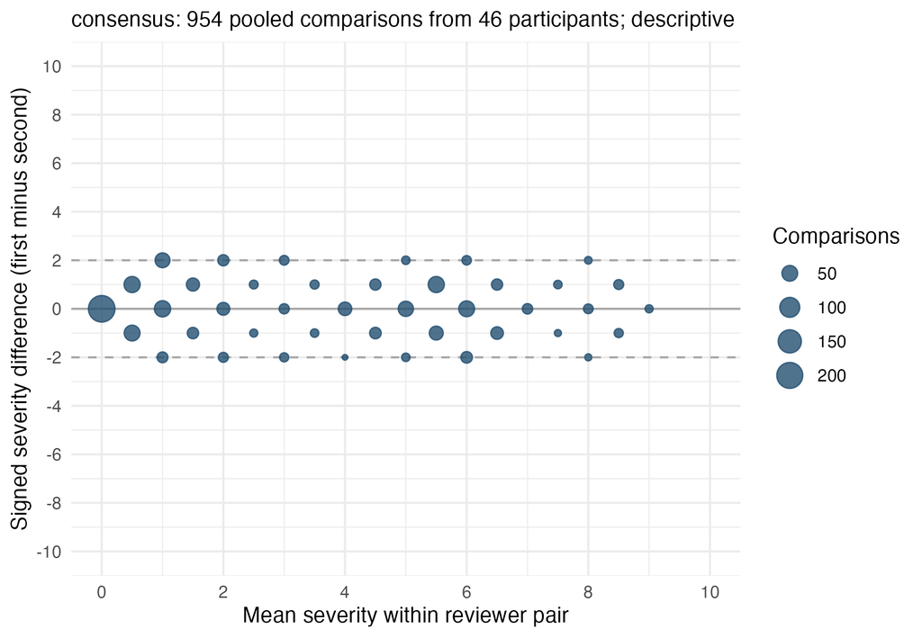

These Bland–Altman-style displays show signed differences. Positive and negative differences may cancel, and reversing the reviewer order reverses their sign. A flat signed trend would therefore not establish constant absolute disagreement across severity. Reference lines at ±2 mark the prespecified tolerance, not estimated limits of agreement. No conventional independent-pair limits of agreement or slope tests are computed for these dependent pooled comparisons.

## Abstract: analysis unit

Original (Internal: REFERENCES/BASIL_CA_combined.pdf, p. 9; authoritative REFERENCES/LLM_OUT/BASIL_CA_combined.jsonl):

Participants: Subsample (n=46) of participant cases for a reliability analysis conducted on 954 paired ratings by 7 clinical assessors across sites.

Revised:

Participants: A subsample of 46 participants was reviewed by 7 independent reviewers using identical standardized clinical information packets. The participant was the analysis unit for multiple-reviewer agreement.

## Abstract: statistical results

Original (Internal: REFERENCES/BASIL_CA_combined.pdf, p. 9; authoritative REFERENCES/LLM_OUT/BASIL_CA_combined.jsonl):

Results: Clinical assessors demonstrated high inter-rater agreement in delirium severity ratings (weighted kappa, κ=0.84), which improved following consensus discussions (κ=0.93). Bland- Altman analysis showed no evidence of systematic disagreement across the full range of severity scores (linear trend for differences over average of two rater scores, b=0.03, 95% confidence interval, -0.13, 0.20).

Revised:

Results: Initial severity agreement was estimated by quadratic-weighted Conger’s κ, 0.844 (95% CI 0.774 to 0.885); after discussion, κ was 0.932 (95% CI 0.904 to 0.948). Binary delirium-presence agreement was 0.771 (95% CI 0.661 to 0.859) initially and 0.810 (95% CI 0.702 to 0.896) after discussion. The sample composition and score distributions are reported in the participant summary.

Revision note: The old numerical values are preserved only in the struck-out quotation. Revised values are inserted by local execution; no result is inferred from the earlier coefficients.

## Abstract: conclusion, first portion

Original (Internal: REFERENCES/BASIL_CA_combined.pdf, p. 9; authoritative REFERENCES/LLM_OUT/BASIL_CA_combined.jsonl):

Conclusions: Trained clinical assessors demonstrated high inter-rater reliability in delirium severity ratings across a reliability sample that included patients with dementia and a wide range of delirium severity. These findings support feasibility of structured clinical assessment

Revised:

Conclusions: Agreement among independent reviewers was evaluated for severity ratings assigned from standardized clinical information packets. The estimates characterize reproducibility under the study’s review procedures, conditional on the information supplied.

## Abstract: conclusion, continuation

Original (Internal: REFERENCES/BASIL_CA_combined.pdf, p. 10; authoritative REFERENCES/LLM_OUT/BASIL_CA_combined.jsonl):

approaches for generating reproducible delirium severity measurements in multisite research studies.

Revised:

The findings concern interpretation of shared information; bedside data collection, rating accuracy, and feasibility were not evaluated.

Revision note: This continuation belongs to the preceding abstract conclusion (PDF pp. 9–10).

## Study purpose

Original (Internal: REFERENCES/BASIL_CA_combined.pdf, p. 12; authoritative REFERENCES/LLM_OUT/BASIL_CA_combined.jsonl):

The present analysis was conducted to evaluate the reliability of data collection by the clinical assessors, which was essential to assure the validity of the overall BASIL II study.

Revised:

The present analysis evaluated agreement among independent reviewers who assigned delirium severity ratings from identical packets of previously collected clinical information. The reliability and fidelity of the original bedside assessments were assumed and were not independently evaluated in this substudy.

## Participant count and missingness

Original (Internal: REFERENCES/BASIL_CA_combined.pdf, p. 12; authoritative REFERENCES/LLM_OUT/BASIL_CA_combined.jsonl):

Each of the 46 cases were rated by 7 clinical assessors resulting in 21 unique pairwise comparisons; this resulted in 966 paired ratings across 46 participants (Supplemental Figure 1). Missing ratings from one clinical assessor (for two participants) resulted in loss of 12 pairwise comparisons, yielding a final reliability sample of 954 paired ratings. Gold standard assessment of delirium for the full BASIL II sample employed an expert panel adjudication process, described previously.9,12 The gold standard diagnoses were used in the present study.

Revised:

The same 7 reviewers rated each of the 46 participant packets, with 2 reviewer ratings missing. Agreement analyses used participant-by-reviewer matrices, retaining the observed ratings for each participant. Descriptive graphics included the 954 observed unique reviewer-pair comparisons (966 possible comparisons minus 12 involving the missing ratings). Expert panel adjudication supplied the study reference-standard diagnoses.

Revision note: Replace gold standard with reference standard elsewhere in manuscript text and legends; preserve the published title in the reference list.

## Statistical analysis: estimators and subgroups

Original (Internal: REFERENCES/BASIL_CA_combined.pdf, p. 14; authoritative REFERENCES/LLM_OUT/BASIL_CA_combined.jsonl):

We evaluated inter-rater reliability for delirium severity scores (0-10 scale) using all possible paired combinations of the 7 clinical assessors (n = 954 unique pairs). We examined both Pearson correlation coefficients and weighted kappa coefficients (with quadratic weights) to summarize the agreement among pairs and confirmed that both approaches yielded identical results. We report these statistics as weighted kappa coefficients. These agreement statistics were calculated before and after the structured consensus discussion to assess its effect on reliability. For the binary classification of delirium (present/absent), we also calculated kappa (κ) before and after consensus to assess diagnostic agreement. To address whether reliability differed by the presence of dementia, we repeated weighted κ and percent agreement analyses stratified by dementia status (present vs. absent, per gold-standard adjudication). We also computed mean absolute differences between paired rater scores as a complementary continuous index of disagreement on the 0-10 severity scale.

Revised:

Agreement on delirium severity (0–10) was summarized with quadratic-weighted Conger’s generalized κ for the fixed panel of 7 reviewers; delirium presence (0/1) was summarized with unweighted Conger’s κ. Calculations used irrCAC::conger.kappa.raw with the complete category sets retained, and available ratings were used without imputing missing scores. Initial and post-discussion estimates were reported separately. The overall unweighted analysis was primary. Dementia-stratified estimates, based on the reference-standard diagnosis, were exploratory and accompanied by participant counts, confidence intervals, exact agreement, agreement within 2 severity points, and mean absolute severity difference. Descriptive agreement measures were calculated within participant and averaged across participants. Percentile 95% confidence intervals were obtained by resampling participants with their reviewer columns intact; the same resampled participants were used to estimate the paired change between stages. The intervals condition on this reviewer panel. Installed package and R versions and the number of bootstrap samples are given in the execution record.

Revision note: Subgroup κ differences depend on subgroup category distributions and cannot alone establish differences in reviewer performance. The revised plan was developed in response to review; remove the earlier claim that this revised plan was prespecified.

## Statistical analysis: plots and participant weights

Original (Internal: REFERENCES/BASIL_CA_combined.pdf, p. 14; authoritative REFERENCES/LLM_OUT/BASIL_CA_combined.jsonl):

We used Bland-Altman analysis20 to examine agreement between rater pairs across the full range of severity (0-10). For each plot, we regressed the difference in scores (Rater A – Rater B) on the pairwise mean score to test whether disagreement varied by severity level. A slope that is approximately 0 indicates no systematic bias in agreement across the severity spectrum. To reduce potential sampling bias and improve representativeness, we applied analytic weights using entropy balancing21 to more closely match the subsample distribution to the full BASIL II sample on site and delirium severity rating.

Revised:

Pooled reviewer-pair scatterplots and signed-difference-versus-mean plots were retained as descriptive displays. Each participant contributed multiple dependent comparisons; no pooled-pair κ, correlation, independent-pair confidence interval, regression test, or conventional limits of agreement were reported. A participant-weighted sensitivity analysis used entropy balancing to match the full enrolled BASIL II cohort on mean reference-standard delirium severity and site proportions. Participant weights entered observed agreement and reviewer-specific category margins in a separate matrix implementation; category agreement weights remained quadratic for severity and unweighted for delirium presence. Sensitivity intervals were obtained by participant bootstrap with the estimated weights held fixed, and thus omit uncertainty from estimating those weights.

## Results: overall agreement

Original (Internal: REFERENCES/BASIL_CA_combined.pdf, p. 15; authoritative REFERENCES/LLM_OUT/BASIL_CA_combined.jsonl):

Figure 1 illustrates the high inter-rater agreement in delirium severity rating prior to and following the consensus process. The weighted kappa was κ=0.84 (95% confidence interval, CI 0.82, 0.86) indicating strong consistency across assessors. Following the consensus meeting, the weighted kappa increased to κ=0.93 (95% CI 0.92, 0.94). Table 1 shows a crosstab of paired delirium presence (clinical assessor diagnosis) before (κ=0.77, 95% CI 0.73, 0.81) and after consensus (κ=0.81, 95% CI 0.77, 0.85), both indicating excellent agreement.22

Revised:

Initial severity agreement among the 7 reviewers was 0.844 (95% CI 0.774 to 0.885) by quadratic-weighted Conger’s κ. Following discussion, κ was 0.932 (95% CI 0.904 to 0.948). For delirium presence, unweighted Conger’s κ was 0.771 (95% CI 0.661 to 0.859) initially and 0.810 (95% CI 0.702 to 0.896) following discussion. Figure 1 shows the observed pooled reviewer-pair comparisons; the agreement table summarizes the participant-level multiple-reviewer analysis.

## Results: dementia strata

Original (Internal: REFERENCES/BASIL_CA_combined.pdf, p. 15; authoritative REFERENCES/LLM_OUT/BASIL_CA_combined.jsonl):

Reliability was also examined separately for patients with and without dementia (Supplemental Table 2). Inter-rater agreement was high and comparable across both strata. The weighted kappa was κ=0.85 (95% CI 0.82, 0.88) in cases without dementia and κ= 0.84 (95% CI 0.81, 0.86) in cases with dementia prior to consensus, improving to κ=0.94 and κ=0.93 after consensus. Percent agreement reached 100 in both strata following consensus. Mean absolute differences between paired rater scores were higher in dementia cases (1.20 pre, 0.77 post) than non-dementia cases (0.84 pre, 0.52 post) but remained within the prespecified 2- point rater agreement window.

Revised:

Exploratory estimates for participants with and without reference-standard dementia are shown in the agreement table, with subgroup participant counts and bootstrap confidence intervals. Exact agreement and agreement within 2 points are reported separately. The within-2-point percentage describes a tolerance criterion, while mean absolute difference summarizes the average discrepancy; a mean below 2 does not establish that every comparison met the tolerance. The subgroup coefficients were not used to establish equivalent reliability.

Revision note: Subgroup estimates and descriptive percentages should be taken from the locally executed table. The legacy 100% claim must be checked against the revised participant-weighted estimand.

## Results: severity-dependent discrepancies

Original (Internal: REFERENCES/BASIL_CA_combined.pdf, p. 15; authoritative REFERENCES/LLM_OUT/BASIL_CA_combined.jsonl):

To evaluate whether rating discrepancies varied as a function of delirium severity, Bland- Altman analysis was conducted. There was no significant association between the mean severity score and absolute disagreement across rater pairs before (linear regression coefficient, b=0.03, 95% CI -0.13, 0.20) and after consensus (b=-0.01, 95% CI -0.13, 0.12) suggesting that disagreement was not systematically greater at lower or higher ends of the severity spectrum (Figure 2).

Revised:

Figure 2 shows signed differences between reviewers as a function of their mean severity rating. The direction of a difference follows the fixed reviewer ordering. The display describes the observed discrepancies; it does not establish constant absolute disagreement across severity levels, because positive and negative differences may cancel.

## Discussion: scope

Original (Internal: REFERENCES/BASIL_CA_combined.pdf, p. 16; authoritative REFERENCES/LLM_OUT/BASIL_CA_combined.jsonl):

This reliability study embedded in the larger BASIL II cohort shows that trained clinical assessors can follow standardized protocols to produce highly reliable delirium severity ratings across diverse care settings. Inter-rater agreement was strong prior to consensus discussion and improved further after the structured consensus process. Importantly, agreement did not vary across levels of delirium severity, supporting the consistency of this approach across the full clinical spectrum. Agreement was also similarly high in cases with and without dementia, supporting reliability of this approach in the population for whom delirium severity measurement is most clinically needed and most challenging.

Revised:

This substudy evaluated agreement when independent reviewers interpreted identical standardized clinical information packets. Initial and post-discussion estimates characterize 2 stages of that procedure. The design permits a description of agreement conditional on shared information, but does not identify a causal effect of consensus discussion or establish reliability of bedside assessment across sites. Dementia-stratified estimates are exploratory; their precision and dependence on the severity distribution limit conclusions about differences or equivalence between clinical subgroups.

## Discussion: limitations

Original (Internal: REFERENCES/BASIL_CA_combined.pdf, p. 17; authoritative REFERENCES/LLM_OUT/BASIL_CA_combined.jsonl):

A few limitations should be noted. First, the reliability study was conducted on standardized summaries, which were condensed in-person assessments. A bedside clinical impression was incorporated into the standardized materials for review but remained constant across each rater. While this approach minimizes contextual biases, it may not fully reflect clinical variation that may be appreciated at the bedside.24 Second, this relatively small reliability sample (n=46 cases) is sufficient for inter-rater reliability estimation but not well-suited for comparisons across study sites. For site and other levels of analysis, see Boockvar et al.’s report of expert panel ratings using the full BASILII cohort. Third, assessors were part of a research team with dedicated training and time, limiting generalizability to routine clinical care. However, the high reliability achieved across independent raters from multiple disciplines highlights the feasibility of this approach for research studies requiring graded measurement of delirium severity.

Revised:

Agreement was evaluated conditional on standardized packets, which incorporated a single bedside clinical impression shared by all reviewers. Shared errors or omissions may coexist with high reviewer agreement. The substudy therefore did not independently establish the reliability or accuracy of the original assessments. The selected sample and fixed reviewer panel limit generalization beyond comparable cases and review procedures; entropy balancing addresses measured differences in site and reference-standard severity only. Post-discussion ratings share information from the consensus process, and their agreement should be interpreted within that procedure. Feasibility was not measured. Replication requires comparable rigor in both the original clinical assessments and subsequent packet review.

## Figure 1 legend

Original (Internal: REFERENCES/BASIL_CA_combined.pdf, p. 23; authoritative REFERENCES/LLM_OUT/BASIL_CA_combined.jsonl):

Figure 1. Agreement of delirium severity rating before (left panel) and after (right panel) consensus. Scatterplot of delirium severity rating agreement between rater A (horizontal axis) and rater B (vertical axis), shown before (left) and after (right) consensus process. Axis tick labels indicate delirium severity (0-10) and the number of ratings is noted in parentheses. The weighted kappa (κ) between rater A and rater B delirium severity ratings (0-10) prior to the consensus process was 0.84 (95% CI: 0.82, 0.86). After the consensus process, the κ was 0.93 (95% CI 0.92, 0.94).

Revised:

Figure 1. Descriptive pooled reviewer-pair severity ratings before and after discussion. Each point combines observed comparisons at the same 2 severity scores, and point size represents the comparison count. First and second reviewer denote positions within each of the 21 possible unique pairs among 7 reviewers. Participants contribute multiple dependent comparisons; these are not independent observations or ratings from 2 particular reviewers. Multiple-reviewer Conger’s κ estimates are reported in the agreement table.

Revision note: Apply this replacement to the duplicate caption on PDF p. 24 as well. The generated caption reports the locally observed participant and comparison counts.

## Figure 2 legend

Original (Internal: REFERENCES/BASIL_CA_combined.pdf, p. 23; authoritative REFERENCES/LLM_OUT/BASIL_CA_combined.jsonl):

Figure 2. Bland Altman plot of variability in agreement as a function of delirium severity before (left panel), and after (right panel) consensus process. Differences in agreement (y- axis) are shown as a function of average severity ratings, comparing pairs of raters, before (left) and after (right) consensus process The linear trend lines show systematic differences in agreement. Regression coefficients are not importantly different from 0 in both panels b (95% confidence interval) = 0.03 (-0.13, 0.20) before and b = -0.01(-0.13, 0.12) after consensus process. This suggests there were no systematic differences in level of agreement across the spectrum of delirium severity.

Revised:

Figure 2. Descriptive signed severity differences versus mean severity for pooled reviewer-pair comparisons, before and after discussion. Difference is first reviewer minus second reviewer under a fixed ordering; reversing the ordering reverses its sign. Point size represents the comparison count. Lines at ±2 mark the tolerance criterion. The displays do not estimate independent-pair regression uncertainty or conventional limits of agreement, and a flat signed pattern would not establish constant absolute disagreement.

Revision note: Apply this replacement to the duplicate caption on PDF p. 25 as well.

## Supplemental analysis-unit legend

Original (Internal: REFERENCES/BASIL_CA_combined.pdf, p. 27; authoritative REFERENCES/LLM_OUT/BASIL_CA_combined.jsonl):

Supplemental Figure 1. Derivation of 954 Paired Ratings for Inter-Rater Reliability Analysis. The BASIL II study enrolled n=488 participants into the full cohort. From the full cohort, a sample of n=46 participants were selected to create a reliability sample. Cases were selected sequentially to ensure representation of both delirium positive and negative cases across all study sites, with an intended sample size of 25-50 to assure statistical stability. Seven clinical assessors rated delirium severity in each of the participants in the reliability sample. For the analysis, this resulted in 21 unique rater pairs [(7 assessors x 6 pairs)/2], with a total number of possible pairs 21 rater pairs x 46 participants = 966 paired ratings. Because one assessor had missing ratings for two participants, there was a total of 12 missing paired ratings. Thus, the analysis sample was 954 paired ratings.

Revised:

Supplemental Figure 1. Derivation of the reliability sample and descriptive reviewer-pair comparisons. From the enrolled cohort of 488 participants, 46 were selected for standardized packet review by the same 7 independent reviewers. Agreement estimation used participant-by-reviewer matrices. With 2 reviewer ratings missing, 954 of the 966 possible unique reviewer-pair comparisons were available for descriptive graphics. The 954 comparisons were not treated as independent analysis units.

Revision note: Apply this replacement to the duplicate caption on PDF p. 30. Replace the pooled cross-tabulation in Table 1 (p. 26) and legacy subgroup estimates in Supplemental Table 2 (p. 29) with the locally generated agreement tables.

## Items requiring author input

The reviewer-response outline leaves the rating rubric, rationale for the severity measure, possible CAM-S comparison, and several clinical design questions unresolved (Internal: REFERENCES/AMGP-26-510-reviews-RESPONSES.md, Reviewer 2, comments 2–4; Reviewer 3; Reviewer 4). The analysis implements the specified agreement revision. It does not invent rating anchors, equate packet-rating agreement with instrument validity, or add diagnostic sensitivity and specificity without an agreed reference-standard comparison plan. The manuscript describes broad severity anchors on p. 13; a complete rubric and its instructions still require author confirmation.

The retained participant data include reference-standard dementia severity and CAM-S for later author-directed descriptive work. Initial and post-discussion score distributions, missingness, and dementia composition should be checked against the manuscript before submission. Existing numerical claims are replaced only when this report is executed locally.